# Introduction to the survey Package in R

Your Name

2025-12-14

# Introduction

This note introduces the computation of basic statistics from survey data. It focuses on the importance of using sampling weights for bias correction. The note shows examples for continous and categorical variables.

# Packages needed for this and the following sessions

```r
# Install if needed
# install.packages("survey")

# Load the package
library(haven)
library(survey)
library(ggplot2)
library(dplyr)
library(labelled)
library(descr)
```

# Data sets

We will use the health, assests and consumption data for this note.

```r
D3 <- read_dta("p3_Health.dta")
Da <- read_dta("h12_assets.dta")
DE <- read_dta("kir_consumption_agg_final.dta") %>% select(interview__key,  fweight, cons_total)
```

Merging the files with left_join

```r
Ds <- left_join(D3, Da, by = c("interview__key"))
Ds <- left_join(Ds, DE, by = c("interview__key"))
```

# Computing basic descriptives with and without weights

We will use the function `freq()` from the `descr` package to tabulate the proportion of people with refrigerator.

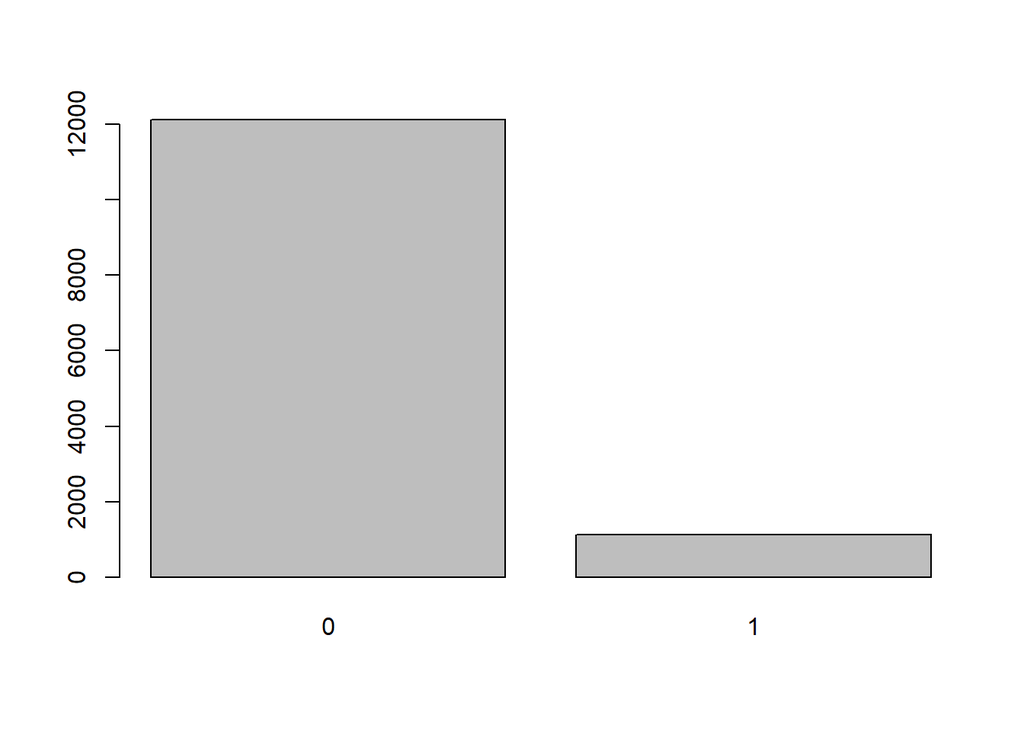

```
## Refrigerator
##       Frequency   Percent Valid Percent
## 0         12128 9.156e+01        91.567
## 1          1117 8.433e+00         8.433
## NA's          1 7.549e-03
## Total     13246 1.000e+02       100.000
```

```r
freq(Ds$h1201__7)
```

The `freq()` function allows integrating sampling weights but first we need to find them:

```r
names(D)
```

[output not shown]

We note that the sampling weights are called `fweight`. To use them we just simply add `Ds$fweight`.

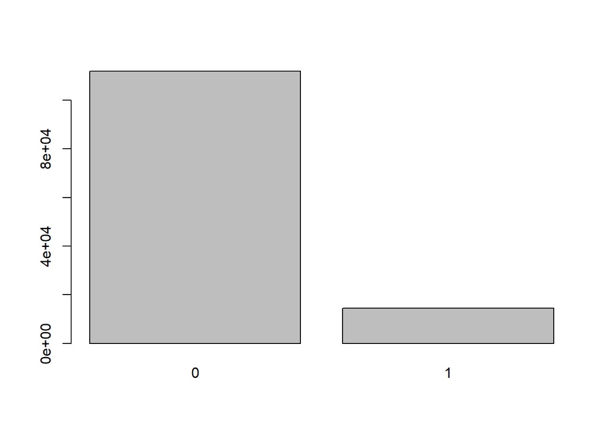

```
## Refrigerator
##       Frequency   Percent Valid Percent
## 0     1.119e+05 8.852e+01         88.52
## 1     1.451e+04 1.148e+01         11.48
## NA's  3.849e+00 3.044e-03
## Total 1.265e+05 1.000e+02        100.00
```

```r
freq(Ds$h1201__7, Ds$fweight)
```

## Crosstabulations

Crosstabulation are one of the most used descriptive statistics in survey data analysis. These involve the tabulation of two categorical variables. The function `crosstab()` from the `descr` package performs simple crosstabulations

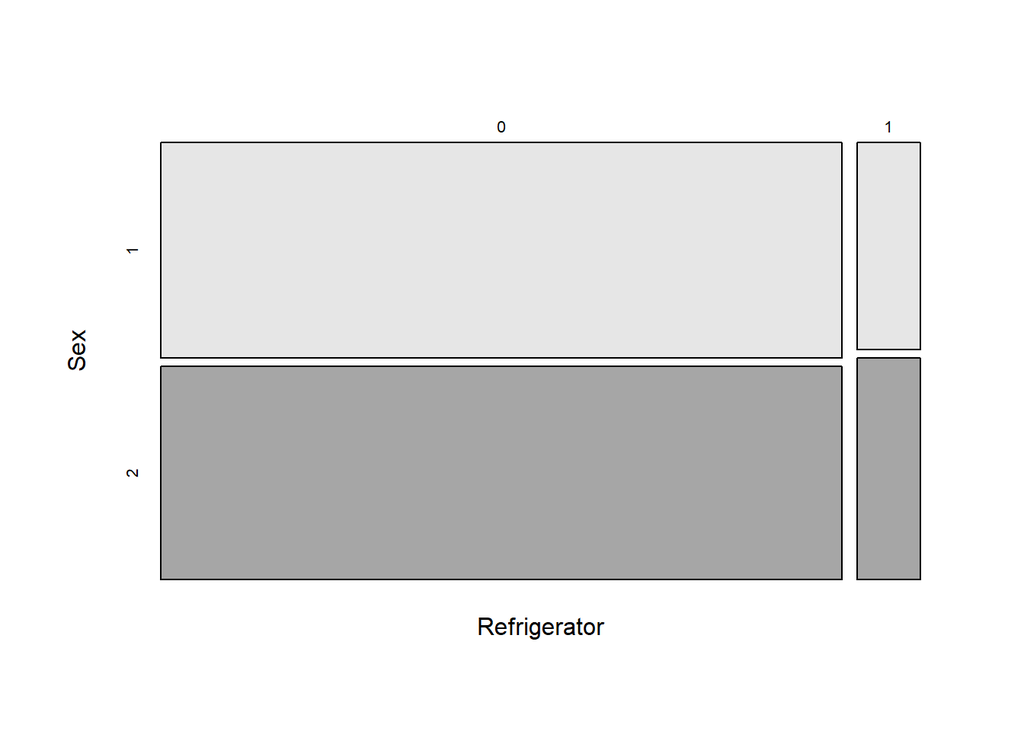

```
##    Cell Contents
## |-------------------------|
## |                   Count |
## |-------------------------|
##
## ==============================
##          Refrigerator
## Sex          0       1   Total
## ------------------------------
## 1         6090     539    6629
## ------------------------------
## 2         6038     578    6616
## ------------------------------
## Total    12128    1117   13245
## ==============================
```

```r
crosstab(Ds$sex, Ds$h1201__7)
```

One problem with the table above are the labels. We know that Ds$h1201__7==1 means having refrigerator. We will assign labels with the `labelled()` function.

```r
Ds$h1201__7 <- labelled(Ds$h1201__7,
                        labels = c("Lacks" = 0, "Has" = 1))
crosstab(as_factor(Ds$sex), as_factor(Ds$h1201__7), plot=F)
```

```
##    Cell Contents
## |-------------------------|
## |                   Count |
## |-------------------------|
##
## ===============================
##           as_factor(Ds$h1201__7)
## Sex       Lacks     Has   Total
## -------------------------------
## Male       6090     539    6629
## -------------------------------
## Female     6038     578    6616
## -------------------------------
## Total     12128    1117   13245
## ===============================
```

One problem of the above table is that it simply shows the absolute numbers and often we are interested in getting the proportions by row as we would like to compare the proportions by gender.

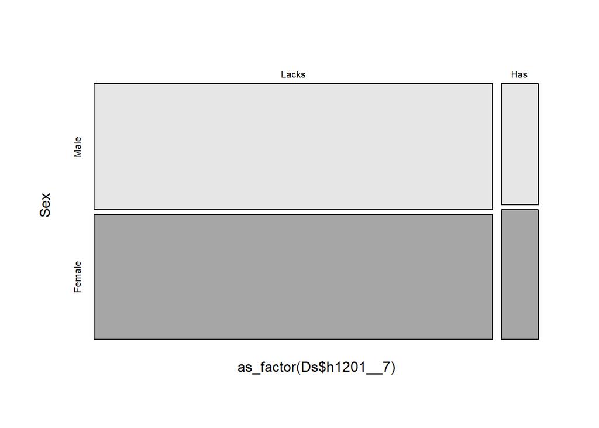

```
##    Cell Contents
## |-------------------------|
## |                   Count |
## |             Row Percent |
## |-------------------------|
##
## ===============================
##           as_factor(Ds$h1201__7)
## Sex       Lacks     Has   Total
## -------------------------------
## Male      6090     539    6629
##           91.9%    8.1%   50.0%
## -------------------------------
## Female    6038     578    6616
##           91.3%    8.7%   50.0%
## -------------------------------
## Total    12128    1117   13245
## ===============================
```

```r
crosstab(as_factor(Ds$sex), as_factor(Ds$h1201__7), prop.r=T)
```

Now, to include the sampling weights, we simply include this option `w=Ds$fweight)`. In this case make little difference.

```r
crosstab(as_factor(Ds$sex), as_factor(Ds$h1201__7), prop.r=T, w=Ds$fweight, plot=F)
```

```
##    Cell Contents
## |-------------------------|
## |                   Count |
## |             Row Percent |
## |-------------------------|
##
## ==================================
##           as_factor(Ds$h1201__7)
## Sex        Lacks      Has    Total
## ----------------------------------
## Male      55481     7085    62566
##            88.7%    11.3%    49.5%
## ----------------------------------
## Female    56460     7430    63890
##            88.4%    11.6%    50.5%
## ----------------------------------
## Total    111941    14515   126456
## ==================================
```

To show a better example we will use the `Ds$Hearing` variable.

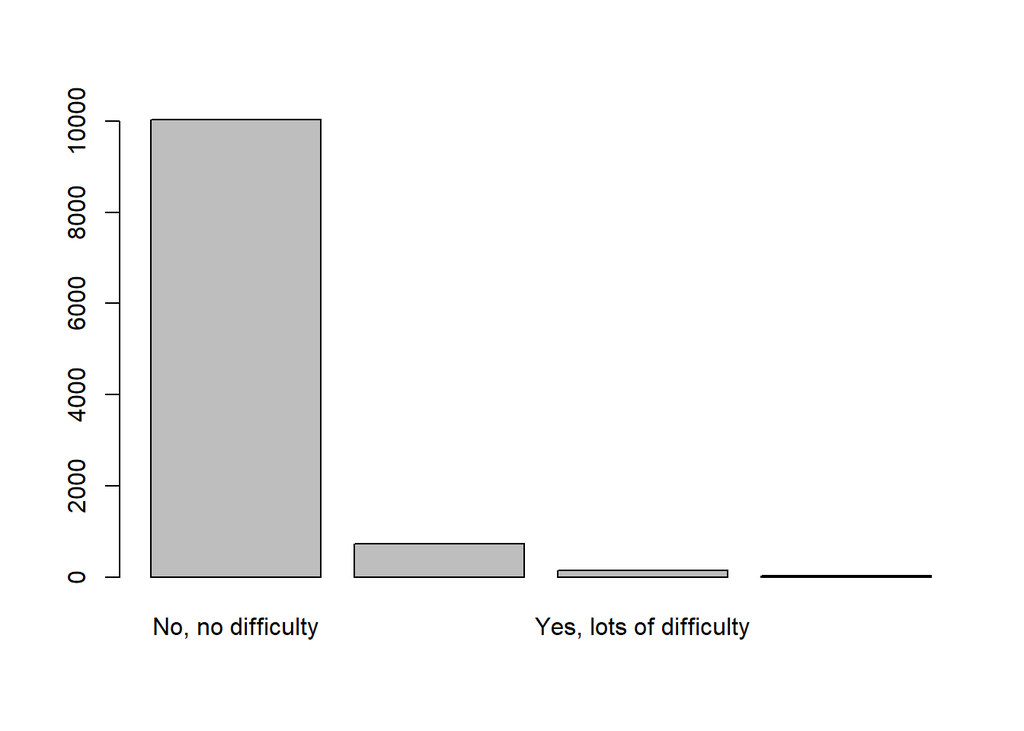

```
## Hearing
##                         Frequency  Percent Valid Percent
## No, no difficulty           10033  75.7436       91.8941
## Yes, some difficulty          723   5.4583        6.6221
## Yes, lots of difficulty       139   1.0494        1.2731
## Cannot do at all               23   0.1736        0.2107
## NA's                         2328  17.5751
## Total                       13246 100.0000      100.0000
```

```r
freq(as_factor(Ds$Hearing))
```

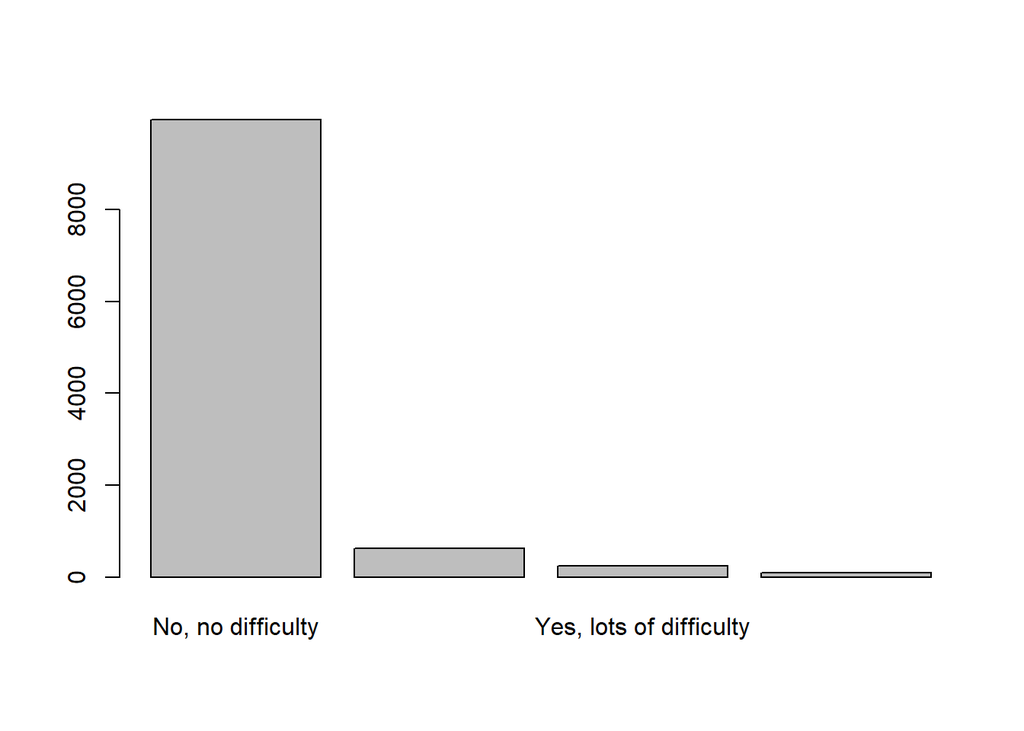

```
## Walking
##                         Frequency  Percent Valid Percent
## No, no difficulty            9963  75.2152       91.2530
## Yes, some difficulty          620   4.6807        5.6787
## Yes, lots of difficulty       240   1.8119        2.1982
## Cannot do at all               95   0.7172        0.8701
## NA's                         2328  17.5751
## Total                       13246 100.0000      100.0000
```

```r
freq(as_factor(Ds$Walking))
```

Now with weights

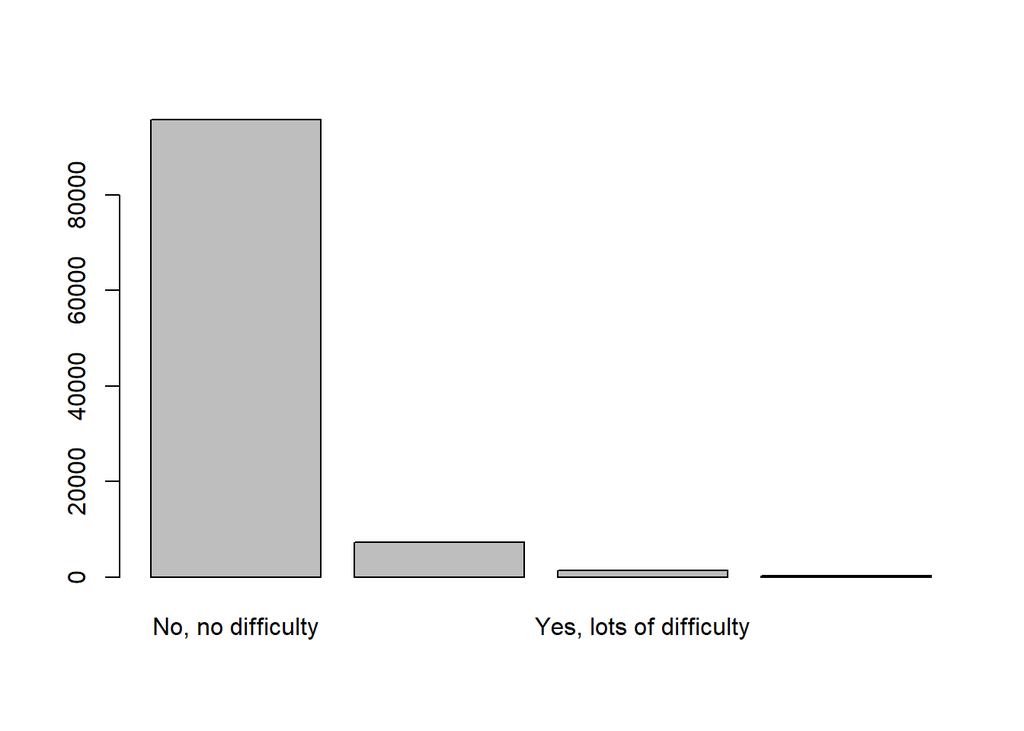

```
## Hearing
##                         Frequency  Percent Valid Percent
## No, no difficulty         95730.9  75.7003       91.5032
## Yes, some difficulty       7229.5   5.7168        6.9102
## Yes, lots of difficulty    1400.8   1.1077        1.3390
## Cannot do at all            259.1   0.2049        0.2476
## NA's                      21840.1  17.2703
## Total                    126460.4 100.0000      100.0000
```

```r
freq(as_factor(Ds$Hearing), Ds$fweight)
```

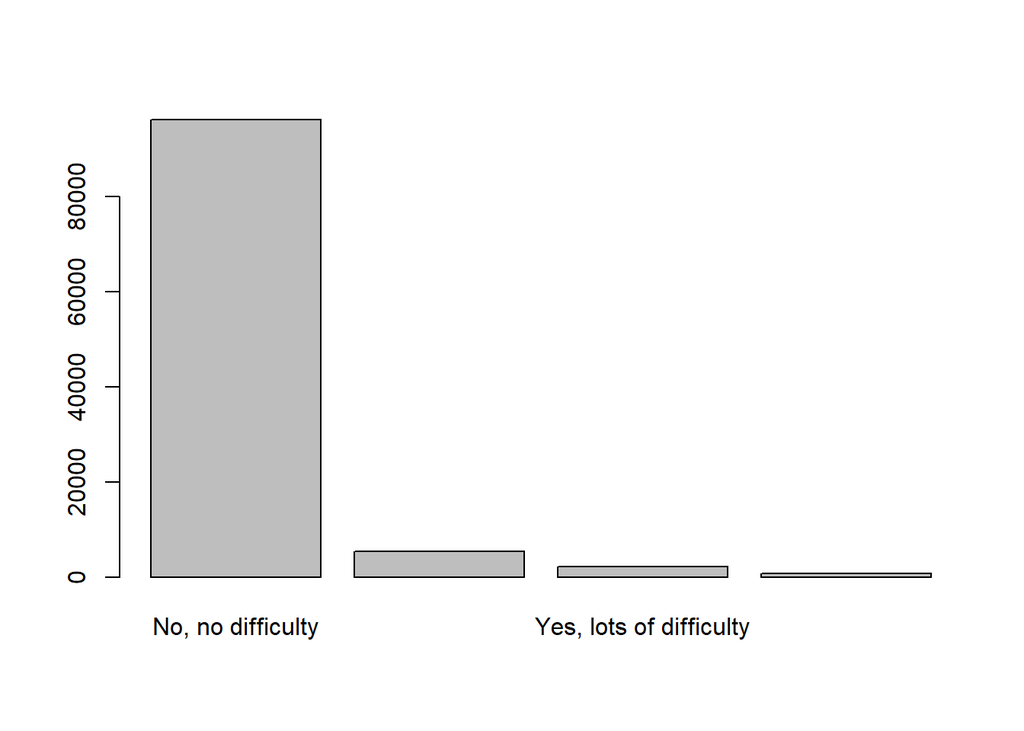

```
## Walking
##                         Frequency  Percent Valid Percent
## No, no difficulty         96221.4  76.0882       91.9720
## Yes, some difficulty       5405.4   4.2744        5.1667
## Yes, lots of difficulty    2181.0   1.7246        2.0847
## Cannot do at all            812.5   0.6425        0.7766
## NA's                      21840.1  17.2703
## Total                    126460.4 100.0000      100.0000
```

```r
freq(as_factor(Ds$Walking), Ds$fweight)
```

## Weightted continous variables

For the case of continous variables we often are interested in computing avergaes of measures of dispersion.

```r
mean(Ds$age)
```

```
## [1] 26.13717
```

The function `weighted.mean()` function is a simple way to introduce weighted computations of the mean.

```r
weighted.mean(Ds$age, Ds$fweight)
```

```
## [1] 25.83125
```

OK but what are we missing? Where is the uncertainty

# Practice:

1. Compute the unweighted and weighted mean of Ds$cons_total
2. Compute the unweighted and weighted proportions of sex, age_grp5
3. Compute the unweighted and weighted crosstabulations of sex with THE PREVIOUSLY CREATED GROUPS 0-20, 21-64, ,65+